# BCB546 R Assignment

Brittany Cavazos

September 30, 2018

# Part One

## Data Inspection

First I need to read in the data and briefly look over the structure of the datasets

```r
genotypes_raw<-read.delim("fang_et_al_genotypes.txt", header = T, sep = "\t")
dim(genotypes_raw)
```

```
## [1] 2782  986
```

```r
head(genotypes_raw[,1:5]) # just showing the output of first five columns for all of these inspections because there are a ton of columns..
```

```
##   Sample_ID   JG_OTU Group abph1.20 abph1.22
## 1     SL-15 T-aust-1 TRIPS      ?/?      ?/?
## 2     SL-16 T-aust-2 TRIPS      ?/?      ?/?
## 3     SL-11 T-brav-1 TRIPS      ?/?      ?/?
## 4     SL-12 T-brav-2 TRIPS      ?/?      ?/?
## 5     SL-18   T-cund TRIPS      ?/?      ?/?
## 6      SL-2 T-dact-1 TRIPS      ?/?      ?/?
```

```r
tail(genotypes_raw[,1:5])
```

```
##      Sample_ID             JG_OTU Group abph1.20 abph1.22
## 2777    SYN262 Zmm-IL-W22-Rrstd_v ZMMIL      C/C      A/A
## 2778     S0398      Zmm-IL-W64A_a ZMMIL      G/G      A/A
## 2779     S1636    Zmm-IL-W64A_b_s ZMMIL      G/G      A/A
## 2780    CU0201        Zmm-IL-WD_f ZMMIL      C/C      A/A
## 2781     S0215         Zmm-IL-Wf9 ZMMIL      G/G      A/A
## 2782    CU0202  Zmm-IL-Yu796_NS_f ZMMIL      C/C      A/A
```

```r
# str(genotypes_raw) output is pretty long
snp_pos<-read.delim("snp_position.txt", header = T, sep = "\t")
dim(snp_pos)
```

```
## [1] 983  15
```

```r
head(snp_pos[,1:5])
```

```
##     SNP_ID cdv_marker_id Chromosome  Position alt_pos
## 1 abph1.20          5976          2  27403404
## 2 abph1.22          5978          2  27403892
## 3    ae1.3          6605          5 167889790
## 4    ae1.4          6606          5 167889682
## 5    ae1.5          6607          5 167889821
## 6    an1.4          5982          1 240498509
```

```r
tail(snp_pos[,1:5])
```

```
##     SNP_ID cdv_marker_id Chromosome  Position alt_pos
## 978 zap1.2          3514          2 233128584
## 979 zen1.1          3519    unknown   unknown
## 980 zen1.2          3520    unknown   unknown
## 981 zen1.4          3521    unknown   unknown
## 982 zfl2.6          6463          2  12543294
## 983 zmm3.4          3527          9  16966348
```

```r
# str(snp_pos)
```

Next I need to transpose the data and subset to maize and teosinte datasets. For maize: Group = ZMMIL, ZMMLR, and ZMMMR

```r
summary(genotypes_raw$Group)
```

```
## TRIPS ZDIPL ZLUXR ZMHUE ZMMIL ZMMLR ZMMMR ZMPBA ZMPIL ZMPJA ZMXCH ZMXCP
##    22    15    17    10   290  1256    27   900    41    34    75    69
## ZMXIL ZMXNO ZMXNT ZPERR
##     6     7     4     9
```

```r
  # for ZMMIL, ZMMLR and ZMMMR, we want a total maize subset that is 1573 rows long
maize_raw<-dplyr::filter(genotypes_raw, Group == "ZMMIL" | Group == "ZMMLR" | Group == "ZMMMR")
  # there is probaby a shorter way of doing this but it works

  # now to transpose it to have SNP ID as columns
names(maize_raw)[1:25]
```

```
##  [1] "Sample_ID" "JG_OTU"    "Group"     "abph1.20"  "abph1.22"
##  [6] "ae1.3"     "ae1.4"     "ae1.5"     "an1.4"     "ba1.6"
## [11] "ba1.9"     "bt2.5"     "bt2.7"     "bt2.8"     "Fea2.1"
## [16] "Fea2.5"    "id1.3"     "lg2.11"    "lg2.2"     "pbf1.1"
## [21] "pbf1.2"    "pbf1.3"    "pbf1.5"    "pbf1.6"    "pbf1.7"
```

```r
maize_T<-as.data.frame(t(maize_raw))
dim(maize_T)
```

```
## [1]  986 1573
```

```r
Maize_IDs<-as.character(maize_raw$Sample_ID)
colnames(maize_T)<-Maize_IDs
```

For teosinte: Group = ZMPBA, ZMPIL, and ZMPJA

```r
teosinte_raw<-dplyr::filter(genotypes_raw, Group == "ZMPBA" | Group == "ZMPIL" | Group == "ZMPJA")
  # there is probaby a shorter way of doing this but it works
  # should be 975 rows after looking at summary(genotypes$Group)
dim(teosinte_raw)
```

```
## [1] 975 986
```

```r
  # not to transpose it to have SNP ID as columns
names(teosinte_raw)[1:25]
```

```
##  [1] "Sample_ID" "JG_OTU"    "Group"     "abph1.20"  "abph1.22"
##  [6] "ae1.3"     "ae1.4"     "ae1.5"     "an1.4"     "ba1.6"
## [11] "ba1.9"     "bt2.5"     "bt2.7"     "bt2.8"     "Fea2.1"
## [16] "Fea2.5"    "id1.3"     "lg2.11"    "lg2.2"     "pbf1.1"
## [21] "pbf1.2"    "pbf1.3"    "pbf1.5"    "pbf1.6"    "pbf1.7"
```

```r
teosinte_T<-as.data.frame(t(teosinte_raw))
dim(teosinte_T)
```

```
## [1] 986 975
```

```r
Teosinte_IDs<-as.character(teosinte_raw$Sample_ID)
colnames(teosinte_T)<-Teosinte_IDs # after transposing we got weird column names so this is a way to fix that
```

Now I need to join together the snp_pos with the other two data sets, but I only need a couple columns from the snp data set

```r
names(snp_pos)
```

```
##  [1] "SNP_ID"               "cdv_marker_id"        "Chromosome"
##  [4] "Position"             "alt_pos"              "mult_positions"
##  [7] "amplicon"             "cdv_map_feature.name" "gene"
## [10] "candidate.random"     "Genaissance_daa_id"   "Sequenom_daa_id"
## [13] "count_amplicons"      "count_cmf"            "count_gene"
```

```r
snp_pos<-dplyr::select(snp_pos, SNP_ID, Chromosome, Position)
  # usally writing over data frames isn't great but this is probably fine
```

Now I need to prep the data sets for merges - we will join maize/teosinte with snp_pos by snp id

```r
# need to add a column in both maize and teosinte that is the snp id - currently its only as the rowname
row.names(snp_pos)<-as.character(snp_pos$SNP_ID)

maize_T_forjoin<-maize_T[4:986,] # to join the snpid info we have to get rid of some of the sample info, we can tack this back on at the end if we need to
teosinte_T_forjoin<-teosinte_T[4:986,]

maizejoined<-merge(snp_pos, maize_T_forjoin, by = "row.names", all = F)
dim(maizejoined)
```

```
## [1]  983 1577
```

```r
maizejoinedF<-dplyr::select(maizejoined, -Row.names)
teosintejoined<-merge(snp_pos, teosinte_T_forjoin, by = "row.names", all = F)
dim(teosintejoined)
```

```
## [1] 983 979
```

```r
teosintejoinedF<-dplyr::select(teosintejoined, -Row.names) # F for final
```

## Data Processing

*For Maize*

Now we need to make 10 files (1 for each chromosome) with SNPs ordered based on increasing position values and with missing data encoded by this symbol: ? #

```r
head(maizejoinedF[maizejoinedF$Chromosome == 1,]) # they are currently out of order
```

```
##         SNP_ID Chromosome  Position ZDP_0752a ZDP_0793a ZDP_0612a
## 6        an1.4          1 240498509       C/G       C/G       C/C
## 14       id1.3          1 238902078       C/T       C/T       C/C
## 31  PZA00010.5          1 119703101       C/C       A/C       A/A
## 32 PZA00013.10          1 263276247       T/T       ?/?       A/A
## 33 PZA00013.11          1 263276005       C/C       C/C       C/C
## 34  PZA00013.9          1 263276335       T/T       T/T       T/T
##    ZDP_0602a ZDP_0581a ZDP_0552a ZDP_0543a ZDP_0042a ZDP_0121a ZDP_0101b
## 6        C/C       C/C       C/C       C/C       C/C       C/C       C/C
## 14       C/C       C/T       C/C       C/C       C/C       C/C       C/T
## 31       A/A       A/A       A/C       C/C       A/A       A/A       A/A
## 32       A/A       A/A       A/A       A/A       A/A       A/A       A/A
## 33       T/T       C/T       C/T       C/T       T/T       T/T       T/T
## 34       A/A       A/T       A/T       A/T       A/A       A/A       A/A
##    ZDP_0087a ZDP_0033a ZDP_0373b ZDP_0168a ZDP_0169a ZDP_0517b ZDP_1098a
```

[output cut: 1462 more lines]

```r
# first let's make chromosome and position numeric
maizejoinedF$Chromosome<-as.numeric(maizejoinedF$Chromosome)
maizejoinedF$Position<-as.numeric(maizejoinedF$Position)
# sort by chromosome, then position
library(dplyr) # not totally sure if this is needed or not
maizejoined_sorted <- maizejoinedF %>% group_by(Chromosome)
maizejoined_sorted <- maizejoined_sorted %>% arrange(Position, .by_group = T)
```

Making the for loop by subsetting the data by already ordered chromosomes

```r
#this creates files that are pretty big and actually ended up crashing rstudio... they are commented out for now
for (i in 1:10) {
  Chr_i<- dplyr::filter(maizejoined_sorted, Chromosome == i)
  filename <- paste("MaizeChromosome", i, ".txt", sep="")
  write.table(Chr_i, file = filename, sep = "\t")
}
```

To make the second 10 files in the reverse order with missing data encoded by “-”, we need to reverse the sorting and replace ? with -

```r
maizejoined_reverse <- maizejoinedF %>% group_by(Chromosome)
maizejoined_reverse <- maizejoined_reverse %>% arrange(desc(Position), .by_group = T)
head(maizejoined_reverse)
```

```
## # A tibble: 6 x 1,576
## # Groups:   Chromosome [1]
##   SNP_ID Chromosome Position ZDP_0752a ZDP_0793a ZDP_0612a ZDP_0602a
##   <fct>       <dbl>    <dbl> <fct>     <fct>     <fct>     <fct>
## 1 PZA00~          1      937 C/C       C/C       C/C       C/C
## 2 PZA00~          1      933 G/G       A/G       A/G       G/G
## 3 PZA00~          1      932 A/G       A/G       ?/?       ?/?
## 4 PZA00~          1      922 A/A       A/A       A/A       A/A
## 5 PZA00~          1      918 A/A       A/A       A/A       A/A
## 6 PZA00~          1      911 A/T       A/A       T/T       T/T
## # ... with 1,569 more variables: ZDP_0581a <fct>, ZDP_0552a <fct>,
## #   ZDP_0543a <fct>, ZDP_0042a <fct>, ZDP_0121a <fct>, ZDP_0101b <fct>,
## #   ZDP_0087a <fct>, ZDP_0033a <fct>, ZDP_0373b <fct>, ZDP_0168a <fct>,
## #   ZDP_0169a <fct>, ZDP_0517b <fct>, ZDP_1098a <fct>, ZDP_0591a <fct>,
## #   ZDP_0258a <fct>, ZDP_0009a <fct>, ZDP_0016a <fct>, ZDP_0010a <fct>,
## #   ZDP_0018a <fct>, ZDP_0647b <fct>, ZDP_1064b <fct>, ZDP_1053a <fct>,
## #   ZDP_1445b <fct>, ZDP_0163a <fct>, ZDP_0164a <fct>, ZDP_0166a <fct>,
## #   ZDP_0839a <fct>, ZDP_0849a <fct>, ZDP_0858b <fct>, ZDP_0184b <fct>,
## #   ZDP_0179a <fct>, ZDP_0180a <fct>, ZDP_1021a <fct>, ZDP_0181a <fct>,
## #   ZDP_1004a <fct>, S1799 <fct>, ZDP_0856a <fct>, ZDP_0915b <fct>,
## #   ZDP_1194b <fct>, ZDP_1476a <fct>, ZDP_0935a <fct>, ZDP_0197a <fct>,
## #   ZDP_0206a <fct>, ZDP_0195a <fct>, ZDP_0051a <fct>, ZDP_0054a <fct>,
## #   ZDP_0052a <fct>, ZDP_0675b <fct>, ZDP_0791a <fct>, ZDP_0814a <fct>,
## #   ZDP_0122a <fct>, ZDP_0090a <fct>, ZDP_0083a <fct>, ZDP_0084a <fct>,
## #   ZDP_0061a <fct>, ZDP_0561a <fct>, ZDP_0057a <fct>, ZDP_0570a <fct>,
## #   ZDP_0899b <fct>, ZDP_0888b <fct>, ZDP_1104a <fct>, ZDP_1162a <fct>,
## #   S1579 <fct>, ZDP_0634a <fct>, S1843 <fct>, ZDP_0689b <fct>,
## #   ZDP_0733b <fct>, ZDP_0758b <fct>, ZDP_1003b <fct>, ZDP_1012a <fct>,
## #   ZDP_0640b <fct>, ZDP_0153a <fct>, ZDP_0154a <fct>, ZDP_1020a <fct>,
## #   S1822 <fct>, ZDP_0994a <fct>, ZDP_1208a <fct>, ZDP_1489a <fct>,
## #   ZDP_0123b <fct>, ZDP_1010a <fct>, ZDP_0001a <fct>, ZDP_0174a <fct>,
## #   ZDP_0178a <fct>, ZDP_1221b <fct>, ZDP_1481a <fct>, ZDP_0988a <fct>,
## #   ZDP_0456a <fct>, ZDP_0368b <fct>, ZDP_0376a <fct>, BKN_003 <fct>,
## #   BKN_004 <fct>, ZDP_0396a <fct>, ZDP_0417a <fct>, ZDP_0563a <fct>,
## #   ZDP_0727a <fct>, ZDP_0746b <fct>, ZDP_0756b <fct>, ZDP_1126a <fct>,
## #   ZDP_1186a <fct>, ZDP_1100a <fct>, ...
```

```r
# make all of the SNP columns into characters
#as.character(maizejoined_reverse[,4])

maizejoined_reverse[,4:1576]<-(as.character(unlist(maizejoined_reverse[,4:1576])))
tail(maizejoined_reverse[,4:1576], n=2)
```

```
## # A tibble: 2 x 1,573
##   ZDP_0752a ZDP_0793a ZDP_0612a ZDP_0602a ZDP_0581a ZDP_0552a ZDP_0543a
##   <chr>     <chr>     <chr>     <chr>     <chr>     <chr>     <chr>
## 1 A/A       A/A       G/G       G/G       A/G       G/G       A/G
## 2 ?/?       T/T       C/C       C/C       C/T       C/C       C/T
## # ... with 1,566 more variables: ZDP_0042a <chr>, ZDP_0121a <chr>,
## #   ZDP_0101b <chr>, ZDP_0087a <chr>, ZDP_0033a <chr>, ZDP_0373b <chr>,
## #   ZDP_0168a <chr>, ZDP_0169a <chr>, ZDP_0517b <chr>, ZDP_1098a <chr>,
## #   ZDP_0591a <chr>, ZDP_0258a <chr>, ZDP_0009a <chr>, ZDP_0016a <chr>,
## #   ZDP_0010a <chr>, ZDP_0018a <chr>, ZDP_0647b <chr>, ZDP_1064b <chr>,
## #   ZDP_1053a <chr>, ZDP_1445b <chr>, ZDP_0163a <chr>, ZDP_0164a <chr>,
## #   ZDP_0166a <chr>, ZDP_0839a <chr>, ZDP_0849a <chr>, ZDP_0858b <chr>,
## #   ZDP_0184b <chr>, ZDP_0179a <chr>, ZDP_0180a <chr>, ZDP_1021a <chr>,
## #   ZDP_0181a <chr>, ZDP_1004a <chr>, S1799 <chr>, ZDP_0856a <chr>,
## #   ZDP_0915b <chr>, ZDP_1194b <chr>, ZDP_1476a <chr>, ZDP_0935a <chr>,
## #   ZDP_0197a <chr>, ZDP_0206a <chr>, ZDP_0195a <chr>, ZDP_0051a <chr>,
## #   ZDP_0054a <chr>, ZDP_0052a <chr>, ZDP_0675b <chr>, ZDP_0791a <chr>,
## #   ZDP_0814a <chr>, ZDP_0122a <chr>, ZDP_0090a <chr>, ZDP_0083a <chr>,
## #   ZDP_0084a <chr>, ZDP_0061a <chr>, ZDP_0561a <chr>, ZDP_0057a <chr>,
## #   ZDP_0570a <chr>, ZDP_0899b <chr>, ZDP_0888b <chr>, ZDP_1104a <chr>,
## #   ZDP_1162a <chr>, S1579 <chr>, ZDP_0634a <chr>, S1843 <chr>,
## #   ZDP_0689b <chr>, ZDP_0733b <chr>, ZDP_0758b <chr>, ZDP_1003b <chr>,
## #   ZDP_1012a <chr>, ZDP_0640b <chr>, ZDP_0153a <chr>, ZDP_0154a <chr>,
## #   ZDP_1020a <chr>, S1822 <chr>, ZDP_0994a <chr>, ZDP_1208a <chr>,
## #   ZDP_1489a <chr>, ZDP_0123b <chr>, ZDP_1010a <chr>, ZDP_0001a <chr>,
## #   ZDP_0174a <chr>, ZDP_0178a <chr>, ZDP_1221b <chr>, ZDP_1481a <chr>,
## #   ZDP_0988a <chr>, ZDP_0456a <chr>, ZDP_0368b <chr>, ZDP_0376a <chr>,
## #   BKN_003 <chr>, BKN_004 <chr>, ZDP_0396a <chr>, ZDP_0417a <chr>,
## #   ZDP_0563a <chr>, ZDP_0727a <chr>, ZDP_0746b <chr>, ZDP_0756b <chr>,
## #   ZDP_1126a <chr>, ZDP_1186a <chr>, ZDP_1100a <chr>, ZDP_0496a <chr>,
## #   ZDP_0280a <chr>, ZDP_1008b <chr>, ...
```

```r
maize_reversefinal<-as.data.frame(lapply(maizejoined_reverse, function(x) {gsub("\\?","-", x)}))
```

Now to write these out

```r
for (i in 1:10) {
  Chr_i<- dplyr::filter(maize_reversefinal, Chromosome == i)
  filename <- paste("MaizeChr_reverseorder", i, ".txt", sep="")
  write.table(Chr_i, file = filename, sep = "\t")
}
```

*For Teosinte*

For teosinte, we will follow the same steps as in the maize files Now we need to make 10 files (1 for each chromosome) with SNPs ordered based on increasing position values and with missing data encoded by this symbol: ? #

```r
head(teosintejoinedF[teosintejoinedF$Chromosome == 1,]) # they are currently out of order
```

```
##         SNP_ID Chromosome  Position S0881 S1057 S1087 S1689 S1697 S1698
## 6        an1.4          1 240498509   C/C   C/C   C/C   C/C   C/C   C/C
## 14       id1.3          1 238902078   C/C   C/C   T/T   C/T   C/C   C/C
## 31  PZA00010.5          1 119703101   C/C   A/C   C/C   A/A   A/C   A/C
## 32 PZA00013.10          1 263276247   A/T   A/A   A/A   A/A   ?/?   A/A
## 33 PZA00013.11          1 263276005   C/C   C/C   C/T   C/C   C/T   C/T
## 34  PZA00013.9          1 263276335   T/T   T/T   A/A   T/T   A/A   A/T
##    S1703 S1704 TA057 TA137 TA153 TA205 TA217 TA242 TA285 TA293 TAMex0091.1
## 6    C/C   C/C   C/C   C/C   C/C   C/C   C/C   C/C   C/C   C/C         C/C
## 14   T/T   C/T   C/T   C/T   C/C   C/C   T/T   C/C   C/C   T/T         C/C
## 31   A/A   A/C   A/C   C/C   A/C   A/C   A/C   C/C   A/A   A/A         A/A
## 32   A/T   A/T   A/T   A/A   A/T   A/T   A/T   A/A   A/T   A/T         ?/?
## 33   C/T   C/C   C/C   T/T   C/C   C/T   C/C   C/C   C/C   C/C         C/C
## 34   A/T   T/T   T/T   T/T   T/T   A/T   T/T   T/T   T/T   T/T         T/T
##    TAMex0153.1 TAMex0238.1 TAMex0396.1 TAMex0446.1 TAMex0455.2 TAMex0520.1
```

[output cut: 1056 more lines]

```r
# first let's make chromosome and position numeric
teosintejoinedF$Chromosome<-as.numeric(teosintejoinedF$Chromosome)
teosintejoinedF$Position<-as.numeric(teosintejoinedF$Position)
# sort by chromosome, then position
library(dplyr) # not totally sure if this is needed or not
teosintejoined_sorted <- teosintejoinedF %>% group_by(Chromosome)
teosintejoined_sorted <- teosintejoined_sorted %>% arrange(Position, .by_group = T)
```

Making the for loop by subsetting the data by already ordered chromosomes

```r
#this creates files that are pretty big and actually ended up crashing rstudio... they are commented out for now
for (i in 1:10) {
  Chr_i<- dplyr::filter(teosintejoined_sorted, Chromosome == i)
  filename <- paste("TeosinteChromosome", i, ".txt", sep="")
  write.table(Chr_i, file = filename, sep = "\t")
}
```

To make the second 10 files in the reverse order with missing data encoded by “-”, we need to reverse the sorting and replace ? with -

```r
teosintejoined_reverse <- teosintejoinedF %>% group_by(Chromosome)
teosintejoined_reverse <- teosintejoined_reverse %>% arrange(desc(Position), .by_group = T)
head(teosintejoined_reverse)
```

```
## # A tibble: 6 x 978
## # Groups:   Chromosome [1]
##   SNP_ID Chromosome Position S0881 S1057 S1087 S1689 S1697 S1698 S1703
##   <fct>       <dbl>    <dbl> <fct> <fct> <fct> <fct> <fct> <fct> <fct>
## 1 PZA00~          1      937 C/C   C/C   C/C   C/C   C/C   C/C   C/C
## 2 PZA00~          1      933 G/G   A/G   G/G   G/G   G/G   G/G   G/G
## 3 PZA00~          1      932 ?/?   G/G   G/G   G/G   ?/?   A/A   A/A
## 4 PZA00~          1      922 A/A   G/G   G/G   G/G   A/A   G/G   G/G
## 5 PZA00~          1      918 A/A   T/T   T/T   T/T   A/A   T/T   T/T
## 6 PZA00~          1      911 T/T   A/A   A/A   T/T   A/T   A/A   T/T
## # ... with 968 more variables: S1704 <fct>, TA057 <fct>, TA137 <fct>,
## #   TA153 <fct>, TA205 <fct>, TA217 <fct>, TA242 <fct>, TA285 <fct>,
## #   TA293 <fct>, TAMex0091.1 <fct>, TAMex0153.1 <fct>, TAMex0238.1 <fct>,
## #   TAMex0396.1 <fct>, TAMex0446.1 <fct>, TAMex0455.2 <fct>,
## #   TAMex0520.1 <fct>, TAMex0608.5 <fct>, TAMex0624.1 <fct>,
## #   TAMex0643.1 <fct>, TAMex0775.2 <fct>, TAMex0930.1 <fct>,
## #   TAMex1083.1 <fct>, TAMex1111.1 <fct>, TAMex1195.2 <fct>,
## #   TAMex1222.2 <fct>, TAMex1308.1 <fct>, TAMex1321.1 <fct>,
## #   TAMex1344.2 <fct>, TAMex1422.2 <fct>, TAMex1488.1 <fct>,
## #   TAMex1561.2 <fct>, TAMex0005.1 <fct>, TAMex0077.1 <fct>,
## #   TAMex0240.2 <fct>, TAMex0299.1 <fct>, TAMex0382.2 <fct>,
## #   TAMex0482.2 <fct>, TAMex0483.1 <fct>, TAMex0488.1 <fct>,
## #   TAMex0509.1 <fct>, TAMex0621.2 <fct>, TAMex0819.1 <fct>,
## #   TAMex0840.1 <fct>, TAMex0855.2 <fct>, TAMex0901.2 <fct>,
## #   TAMex0925.1 <fct>, TAMex0942.1 <fct>, TAMex0966.1 <fct>,
## #   TAMex1005.1 <fct>, TAMex1136.1 <fct>, TAMex1165.1 <fct>,
## #   TAMex1340.1 <fct>, TAMex1349.2 <fct>, TAMex1391.2 <fct>,
## #   TAMex1437.1 <fct>, TAMex1508.4 <fct>, TAMex0050.1 <fct>,
## #   TAMex0106.1 <fct>, TAMex0167.1 <fct>, TAMex0181.2 <fct>,
## #   TAMex0207.2 <fct>, TAMex0438.1 <fct>, TAMex0515.1 <fct>,
## #   TAMex0517.1 <fct>, TAMex0568.1 <fct>, TAMex0645.1 <fct>,
## #   TAMex0667.1 <fct>, TAMex0757.1 <fct>, TAMex0845.2 <fct>,
## #   TAMex0849.3 <fct>, TAMex0918.2 <fct>, TAMex0947.1 <fct>,
## #   TAMex0982.1 <fct>, TAMex1139.2 <fct>, TAMex1298.4 <fct>,
## #   TAMex1348.3 <fct>, TAMex1358.1 <fct>, TAMex1439.2 <fct>,
## #   TAMex1443.1 <fct>, TAMex1467.1 <fct>, TAMex0267.2 <fct>,
## #   TAMex0280.3 <fct>, TAMex0400.1 <fct>, TAMex0403.1 <fct>,
## #   TAMex0412.1 <fct>, TAMex0495.1 <fct>, TAMex0514.1 <fct>,
## #   TAMex0544.1 <fct>, TAMex0587.1 <fct>, TAMex0613.2 <fct>,
## #   TAMex0766.2 <fct>, TAMex0785.1 <fct>, TAMex0874.1 <fct>,
## #   TAMex0897.2 <fct>, TAMex1069.2 <fct>, TAMex1087.1 <fct>,
## #   TAMex1107.1 <fct>, TAMex1160.1 <fct>, TAMex1178.1 <fct>,
## #   TAMex1246.3 <fct>, ...
```

```r
# make all of the SNP columns into characters
#as.character(maizejoined_reverse[,4])

teosintejoined_reverse[,4:978]<-(as.character(unlist(teosintejoined_reverse[,4:978])))
tail(teosintejoined_reverse[,4:978], n=2)
```

```
## # A tibble: 2 x 975
##   S0881 S1057 S1087 S1689 S1697 S1698 S1703 S1704 TA057 TA137 TA153 TA205
##   <chr> <chr> <chr> <chr> <chr> <chr> <chr> <chr> <chr> <chr> <chr> <chr>
## 1 G/G   A/G   A/G   G/G   G/G   G/G   G/G   A/G   G/G   G/G   A/A   G/G
## 2 T/T   C/C   T/T   T/T   C/C   C/C   C/C   T/T   ?/?   ?/?   ?/?   ?/?
## # ... with 963 more variables: TA217 <chr>, TA242 <chr>, TA285 <chr>,
## #   TA293 <chr>, TAMex0091.1 <chr>, TAMex0153.1 <chr>, TAMex0238.1 <chr>,
## #   TAMex0396.1 <chr>, TAMex0446.1 <chr>, TAMex0455.2 <chr>,
## #   TAMex0520.1 <chr>, TAMex0608.5 <chr>, TAMex0624.1 <chr>,
## #   TAMex0643.1 <chr>, TAMex0775.2 <chr>, TAMex0930.1 <chr>,
## #   TAMex1083.1 <chr>, TAMex1111.1 <chr>, TAMex1195.2 <chr>,
## #   TAMex1222.2 <chr>, TAMex1308.1 <chr>, TAMex1321.1 <chr>,
## #   TAMex1344.2 <chr>, TAMex1422.2 <chr>, TAMex1488.1 <chr>,
## #   TAMex1561.2 <chr>, TAMex0005.1 <chr>, TAMex0077.1 <chr>,
## #   TAMex0240.2 <chr>, TAMex0299.1 <chr>, TAMex0382.2 <chr>,
## #   TAMex0482.2 <chr>, TAMex0483.1 <chr>, TAMex0488.1 <chr>,
## #   TAMex0509.1 <chr>, TAMex0621.2 <chr>, TAMex0819.1 <chr>,
## #   TAMex0840.1 <chr>, TAMex0855.2 <chr>, TAMex0901.2 <chr>,
## #   TAMex0925.1 <chr>, TAMex0942.1 <chr>, TAMex0966.1 <chr>,
## #   TAMex1005.1 <chr>, TAMex1136.1 <chr>, TAMex1165.1 <chr>,
## #   TAMex1340.1 <chr>, TAMex1349.2 <chr>, TAMex1391.2 <chr>,
## #   TAMex1437.1 <chr>, TAMex1508.4 <chr>, TAMex0050.1 <chr>,
## #   TAMex0106.1 <chr>, TAMex0167.1 <chr>, TAMex0181.2 <chr>,
## #   TAMex0207.2 <chr>, TAMex0438.1 <chr>, TAMex0515.1 <chr>,
## #   TAMex0517.1 <chr>, TAMex0568.1 <chr>, TAMex0645.1 <chr>,
## #   TAMex0667.1 <chr>, TAMex0757.1 <chr>, TAMex0845.2 <chr>,
## #   TAMex0849.3 <chr>, TAMex0918.2 <chr>, TAMex0947.1 <chr>,
## #   TAMex0982.1 <chr>, TAMex1139.2 <chr>, TAMex1298.4 <chr>,
## #   TAMex1348.3 <chr>, TAMex1358.1 <chr>, TAMex1439.2 <chr>,
## #   TAMex1443.1 <chr>, TAMex1467.1 <chr>, TAMex0267.2 <chr>,
## #   TAMex0280.3 <chr>, TAMex0400.1 <chr>, TAMex0403.1 <chr>,
## #   TAMex0412.1 <chr>, TAMex0495.1 <chr>, TAMex0514.1 <chr>,
## #   TAMex0544.1 <chr>, TAMex0587.1 <chr>, TAMex0613.2 <chr>,
## #   TAMex0766.2 <chr>, TAMex0785.1 <chr>, TAMex0874.1 <chr>,
## #   TAMex0897.2 <chr>, TAMex1069.2 <chr>, TAMex1087.1 <chr>,
## #   TAMex1107.1 <chr>, TAMex1160.1 <chr>, TAMex1178.1 <chr>,
## #   TAMex1246.3 <chr>, TAMex1271.2 <chr>, TAMex1283.1 <chr>,
## #   TAMex1429.2 <chr>, TAMex1452.1 <chr>, TAMex1465.1 <chr>, ...
```

```r
teosinte_reversefinal<-as.data.frame(lapply(teosintejoined_reverse, function(x) {gsub("\\?","-", x)}))
```

Now to write these out

```r
for (i in 1:10) {
  Chr_i<- dplyr::filter(teosinte_reversefinal, Chromosome == i)
  filename <- paste("TeosinteChr_reverseorder", i, ".txt", sep="")
  write.table(Chr_i, file = filename, sep = "\t")
}
```

# Part Two

Use ggplot to visualize our data in this part

First, I need to make tidy datasets for both corn and teosinte

```r
library(reshape2); library(ggplot2)
head(snp_pos)
```

```
##            SNP_ID Chromosome  Position
## abph1.20 abph1.20          2  27403404
## abph1.22 abph1.22          2  27403892
## ae1.3       ae1.3          5 167889790
## ae1.4       ae1.4          5 167889682
## ae1.5       ae1.5          5 167889821
## an1.4       an1.4          1 240498509
```

```r
# I wrote over the original snp_pos to make it only 3 variables so here I'm going back to the orig
SNPs<-read.delim("snp_position.txt", header = T, sep = "\t")

snpMelt<-melt(SNPs, "Chromosome", "SNP_ID")
head(snpMelt)
```

```
##   Chromosome variable    value
## 1          2   SNP_ID abph1.20
## 2          2   SNP_ID abph1.22
## 3          5   SNP_ID    ae1.3
## 4          5   SNP_ID    ae1.4
## 5          5   SNP_ID    ae1.5
## 6          1   SNP_ID    an1.4
```

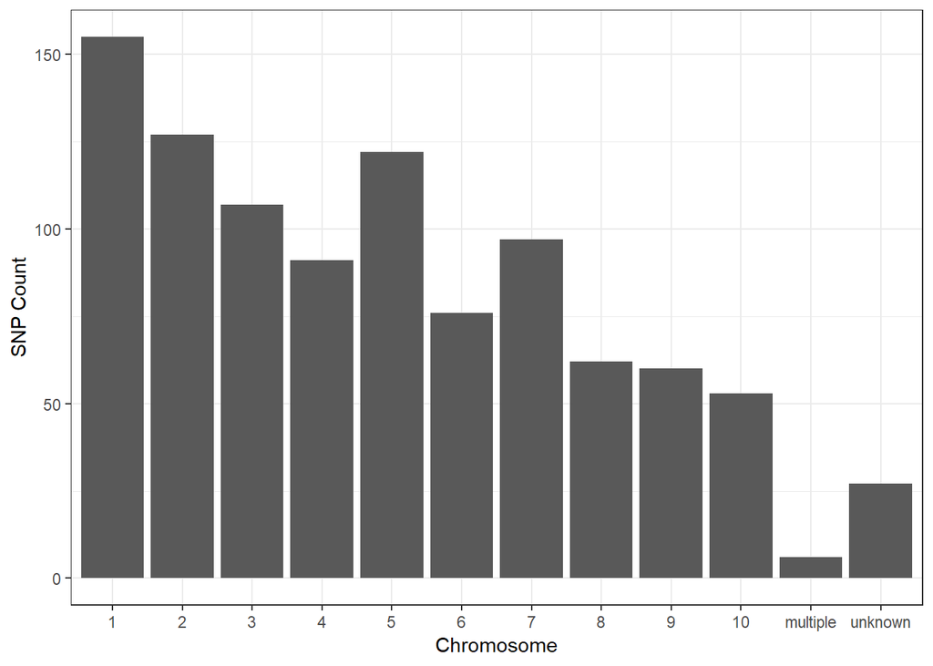

```r
# make chrom. integer so it plots in order
SNPs$Chromosome<-factor(SNPs$Chromosome, levels = c(1:10, "multiple", "unknown"))

ggplot(SNPs) + geom_bar(aes(x=Chromosome)) + theme_bw() + labs(x="Chromosome",y="SNP Count")
```

```r
# SNPS per chromosome
# Plot the total number of SNPs in our dataset on each chromosome. What groups contribute most of these SNPs?
```

Chromosome 1 seems to have the most snps

```r
# Tidy data
tidy_genotypes<-melt(genotypes_raw, c(1,3), c(4:986), variable.name = "SNP_ID", value.name = "SNP") #melting snps by sample id and keeping group
head(tidy_genotypes, n = 40)
```

```
##      Sample_ID Group   SNP_ID SNP
## 1        SL-15 TRIPS abph1.20 ?/?
## 2        SL-16 TRIPS abph1.20 ?/?
## 3        SL-11 TRIPS abph1.20 ?/?
## 4        SL-12 TRIPS abph1.20 ?/?
## 5        SL-18 TRIPS abph1.20 ?/?
## 6         SL-2 TRIPS abph1.20 ?/?
## 7         SL-4 TRIPS abph1.20 ?/?
## 8         SL-6 TRIPS abph1.20 ?/?
## 9         SL-7 TRIPS abph1.20 ?/?
## 10        SL-5 TRIPS abph1.20 ?/?
## 11        SL-3 TRIPS abph1.20 ?/?
## 12        SL-8 TRIPS abph1.20 ?/?
## 13       SL-24 TRIPS abph1.20 ?/?
## 14       SL-22 TRIPS abph1.20 ?/?
```

[output cut: 26 more lines]

```r
SiteStatus <- function(x){
  if(x == "?/?")
    return("NA")
  else if ( x == "A/A" | x == "T/T"| x == "C/C" | x == "G/G")
    return("homozygous")
  else
    return("heterozygous")
}

tidy_genotypes$sitestatus<-as.character(lapply(tidy_genotypes$SNP, FUN = SiteStatus))

# it worked!
```

Now I will sort the dataframe using Group and Species_ID values

```r
tidy_genotypes_sorted <- tidy_genotypes %>% group_by(Group)
tidy_genotypes_sorted <- tidy_genotypes_sorted %>% arrange(Sample_ID, .by_group = T)
tidy_genotypes_sorted <- tbl_df(tidy_genotypes_sorted)
```

Make a graph that shows the proportion of homozygous and heterozygous sites as well as missing data in each species (you won’t be able to see species names) and each group.

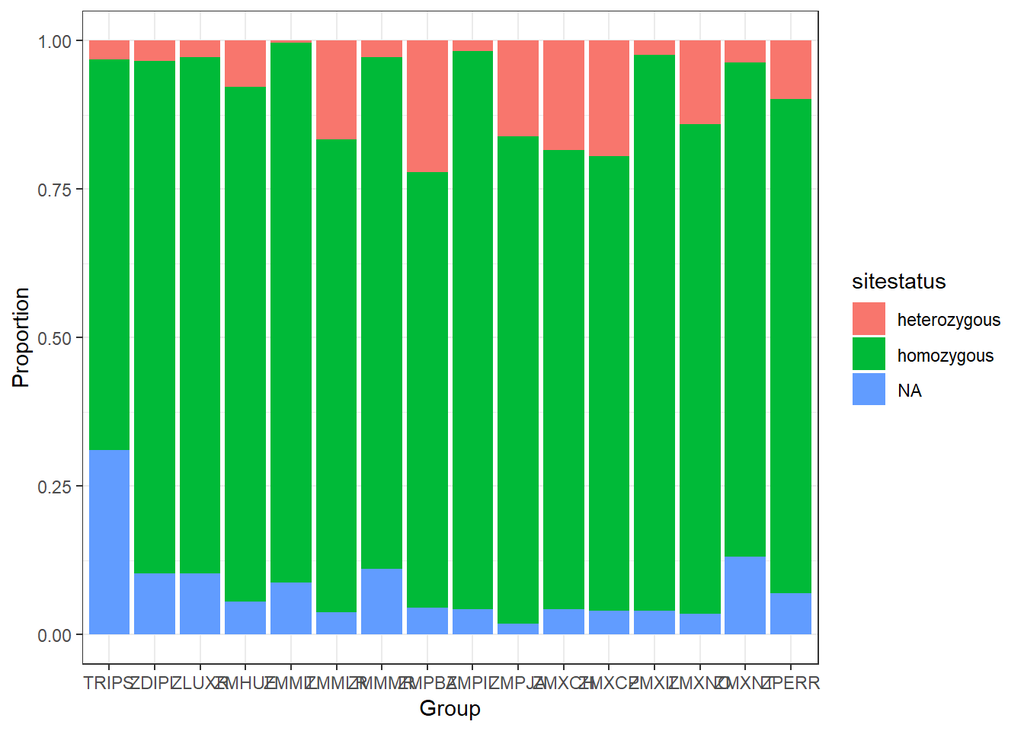

```r
# currently sitestatus is a character so we need to make it a factor
tidy_genotypes_sorted$sitestatus<-as.factor(tidy_genotypes_sorted$sitestatus)
summarygroup <- tidy_genotypes_sorted %>%
  group_by(Group, sitestatus) %>%
  summarise(length(sitestatus)) # this will get number of snps for homo/hetero/na at each group (still not getting at species level though)
colnames(summarygroup)[3]<-"snpcount"


ggplot(summarygroup, aes(Group, snpcount, fill=sitestatus)) +
    geom_bar(stat="identity", position = "fill") +
    labs(x="Group", y="Proportion")+ theme_bw()
```

And a final visualization of my choice

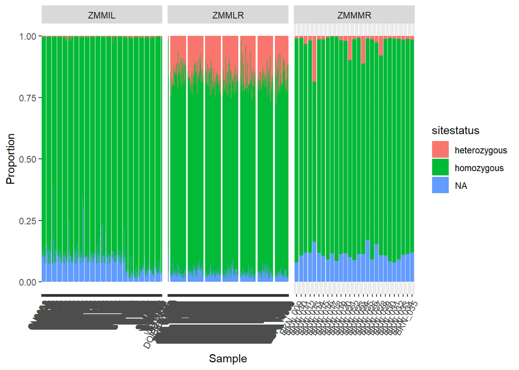

```r
summarysample<- tidy_genotypes_sorted %>%
  group_by(Sample_ID, sitestatus) %>%
  summarise(length(sitestatus))
colnames(summarysample)[3]<-"snpcount"

groupinfo<-select(genotypes_raw, Sample_ID, Group)
summarysample <-merge(summarysample, groupinfo, by = "Sample_ID", all = F)

#for maize
summarysample_maize<-dplyr::filter(summarysample, Group == "ZMMIL" | Group == "ZMMLR" | Group == "ZMMMR")

#maize plot
ggplot(summarysample_maize, aes(Sample_ID, snpcount, fill=sitestatus)) +
    geom_bar(stat="identity", position = "fill") +
    facet_grid(.~Group, scales = "free")+
    labs(x="Sample", y="Proportion")+ theme(axis.text.x = element_text(angle = 60, hjust = 1))
```

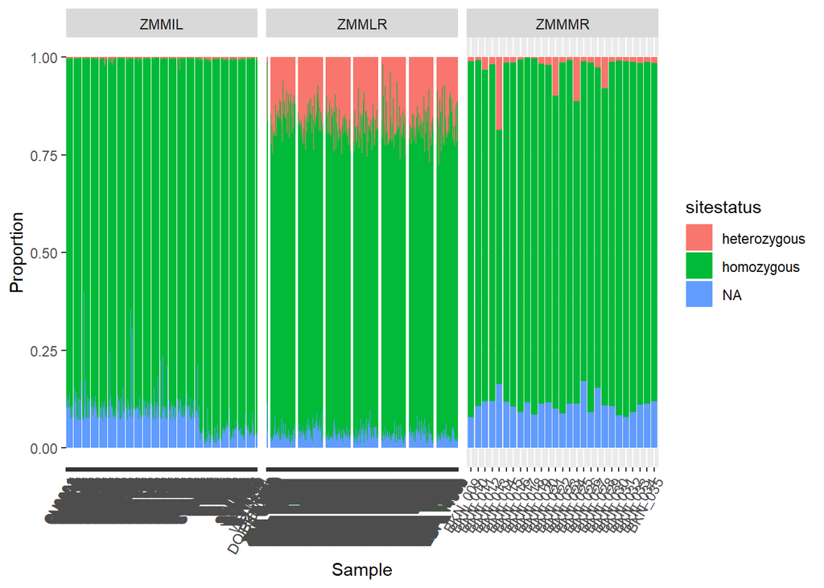

```r
#for teosinte
summarysample_teo<-dplyr::filter(summarysample, Group == "ZMPBA" | Group == "ZMPIL" | Group == "ZMPJA")
ggplot(summarysample_maize, aes(Sample_ID, snpcount, fill=sitestatus)) +
    geom_bar(stat="identity", position = "fill") +
    facet_grid(.~Group, scales = "free")+
    labs(x="Sample", y="Proportion")+ theme(axis.text.x = element_text(angle = 60, hjust = 1))
```

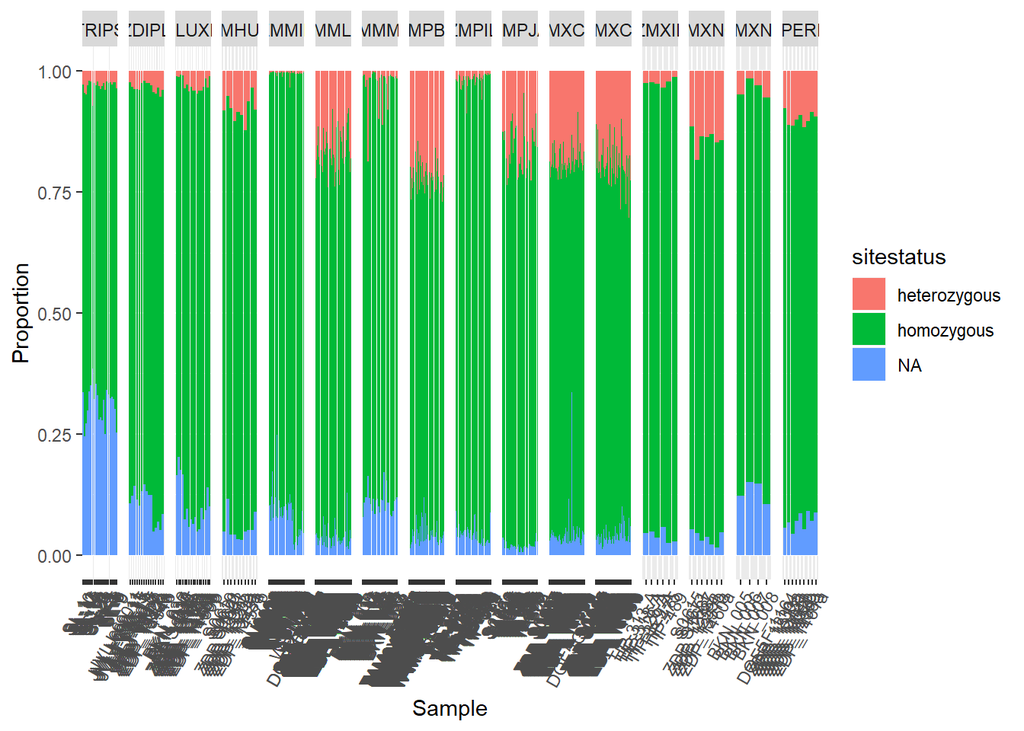

```r
ggplot(summarysample, aes(Sample_ID, snpcount, fill=sitestatus)) +
    geom_bar(stat="identity", position = "fill") +
    facet_grid(.~Group, scales = "free")+
    labs(x="Sample", y="Proportion")+ theme(axis.text.x = element_text(angle = 60, hjust = 1))
```

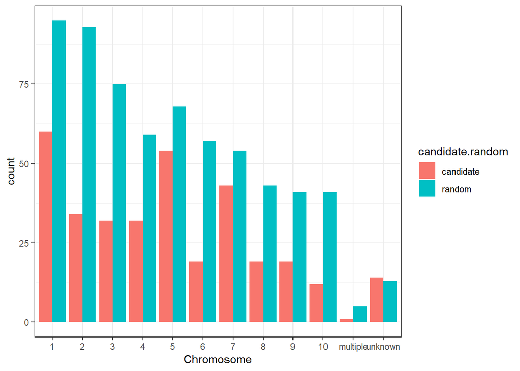

```r
#candidates vs random across chromosomes
ggplot(SNPs) + geom_bar(aes(x=Chromosome, fill = candidate.random), position = "dodge") + theme_bw()
```